# crypto_price_forcasting

```python
import pandas as pd
import numpy as np
import seaborn as sns
from  matplotlib import pyplot as plt

sns.set()
```

```python
SEED = np.random.seed(2023)  # for reproducibility
```

#### Importing the Dataset

The dataset is not in the standard csv format so the data will need to be converted to a dataframe

```python
data_path = "Cryptocurrency_History_Data"
```

```python
def read_data(path):
    with open(path, 'r') as f:
        lines = f.readlines()

    ix = 0
    for (i, line) in enumerate(lines):
        if line.startswith('@DATA'):
            ix = i
            break

    columns = [
        line.split(" ")[1] for line in lines[:ix] if line.startswith('@ATTRIBUTE')
    ]

    data = [
        prepare_row(line) for line in lines[ix+1:]
    ]

    data = [
        line for line in data if len(line) == len(columns)
    ]

    return pd.DataFrame(data = data, columns=columns)
```

```python
def prepare_row(row):
    row = row.replace("\n", "").strip().split(",")
    return [prepare_data_unit(unit) for unit in row]
```

```python
def prepare_data_unit(unit):
    if  unit.isdigit():
        if "." in unit:
            return float(unit)
        return int(unit)

    return unit
```

```python
data = read_data(data_path)
```

# Exploratory Data Analysis

```python
data.head()
```

|  | trade_date | volume | price_usd | price_btc | market_cap | capitalization_change_1_day | USD_price_change_1_day | BTC_price_change_1_day | crypto_name | crypto_type | ticker | max_supply | site_url | github_url | minable | platform_name | industry_name |
| --- | --- | --- | --- | --- | --- | --- | --- | --- | --- | --- | --- | --- | --- | --- | --- | --- | --- |
| 0 | 2016-01-01 | 36278900.0 | 434.33 | 1.0 | 6529299589.0 | 0.0 | 0.0 | 0.0 | Bitcoin | 0.0 | BTC | 21000000.0 | https://bitcoin.org/ | https://github.com/bitcoin/ | 1.0 | XRP | 'Proof of Work (PoW)' |
| 1 | 2016-01-02 | 30096600.0 | 433.44 | 1.0 | 6517390487.0 | -0.0018239478580617 | -0.0020491331476066 | 0.0 | Bitcoin | 0.0 | BTC | 21000000.0 | https://bitcoin.org/ | https://github.com/bitcoin/ | 1.0 | XRP | 'Proof of Work (PoW)' |
| 2 | 2016-01-03 | 39633800.0 | 430.01 | 1.0 | 6467429942.0 | -0.0076657283462844 | -0.0079134366925065 | 0.0 | Bitcoin | 0.0 | BTC | 21000000.0 | https://bitcoin.org/ | https://github.com/bitcoin/ | 1.0 | XRP | 'Proof of Work (PoW)' |
| 3 | 2016-01-04 | 38477500.0 | 433.09 | 1.0 | 6515713340.0 | 0.0074656236608678 | 0.0071626241250203 | 0.0 | Bitcoin | 0.0 | BTC | 21000000.0 | https://bitcoin.org/ | https://github.com/bitcoin/ | 1.0 | XRP | 'Proof of Work (PoW)' |
| 4 | 2016-01-05 | 34522600.0 | 431.96 | 1.0 | 6500393256.0 | -0.0023512519966079 | -0.0026091574499527 | 0.0 | Bitcoin | 0.0 | BTC | 21000000.0 | https://bitcoin.org/ | https://github.com/bitcoin/ | 1.0 | XRP | 'Proof of Work (PoW)' |

```python
#feature cardinality
data.nunique()
```

```
trade_date                        1759
volume                         1036898
price_usd                       402078
price_btc                      2053690
market_cap                     1551095
capitalization_change_1_day    1859661
USD_price_change_1_day         1551435
BTC_price_change_1_day         2099347
crypto_name                       4137
crypto_type                          3
ticker                            3813
max_supply                         650
site_url                          4025
github_url                        2430
minable                              3
platform_name                       41
industry_name                       44
dtype: int64
```

Some of the features unique values make sense, however, features like 'mineable' should have 2 values which will need to be fixed.

```python
data.shape
```

```
(2382623, 17)
```

```python
data.describe()
```

|  | trade_date | volume | price_usd | price_btc | market_cap | capitalization_change_1_day | USD_price_change_1_day | BTC_price_change_1_day | crypto_name | crypto_type | ticker | max_supply | site_url | github_url | minable | platform_name | industry_name |
| --- | --- | --- | --- | --- | --- | --- | --- | --- | --- | --- | --- | --- | --- | --- | --- | --- | --- |
| count | 2382623 | 2382623 | 2382623 | 2382623 | 2382623 | 2382623 | 2382623 | 2382623 | 2382623 | 2382623 | 2382623 | 2382623 | 2382623 | 2382623 | 2382623 | 2382623 | 2382623 |
| unique | 1759 | 1036898 | 402078 | 2053690 | 1551095 | 1859661 | 1551435 | 2099347 | 4137 | 3 | 3813 | 650 | 4025 | 2430 | 3 | 41 | 44 |
| top | 2020-10-20 | 0.0 | 2e-06 | 0.0 | 0.0 | 0.0 | 0.0 | 0.0 | ? | 1.0 | ? | ? | ? | ? | 0.0 | ? | ? |
| freq | 3576 | 209666 | 11399 | 3499 | 416052 | 519845 | 216020 | 3902 | 158849 | 1247697 | 158849 | 1686445 | 161185 | 845307 | 1609043 | 856378 | 677403 |

The summary of the numerical data is not showing which probably means the data is not loading properly

```python
# check for missing values
data.isna().sum()
```

```
trade_date                     0
volume                         0
price_usd                      0
price_btc                      0
market_cap                     0
capitalization_change_1_day    0
USD_price_change_1_day         0
BTC_price_change_1_day         0
crypto_name                    0
crypto_type                    0
ticker                         0
max_supply                     0
site_url                       0
github_url                     0
minable                        0
platform_name                  0
industry_name                  0
dtype: int64
```

```python
data.info()
```

```
<class 'pandas.core.frame.DataFrame'>
RangeIndex: 2382623 entries, 0 to 2382622
Data columns (total 17 columns):
 #   Column                       Dtype
---  ------                       -----
 0   trade_date                   object
 1   volume                       object
 2   price_usd                    object
 3   price_btc                    object
 4   market_cap                   object
 5   capitalization_change_1_day  object
 6   USD_price_change_1_day       object
 7   BTC_price_change_1_day       object
 8   crypto_name                  object
 9   crypto_type                  object
 10  ticker                       object
 11  max_supply                   object
 12  site_url                     object
 13  github_url                   object
 14  minable                      object
 15  platform_name                object
 16  industry_name                object
dtypes: object(17)
memory usage: 309.0+ MB
```

All the features are loaded as objects rather than some as float and int

```python
# duplicated rows
num_duplicates = len(data.loc[data.duplicated(), :])
```

```python
print(f"Number of duplicated rows: {num_duplicates}")
```

```
Number of duplicated rows: 23
```

```python
# observe the minable feature
data["minable"].value_counts()
```

```
minable
0.0    1609043
1.0     614731
?       158849
Name: count, dtype: int64
```

The feature 'mineable' mentioned earlier has a different value rather than NaN.

```python
# replace "?" with NaN
data.replace("?", np.nan, inplace=True)
```

```python
# check for missing values
100 * data.isnull().sum() / len(data)
```

```
trade_date                      0.000000
volume                          0.000000
price_usd                       0.000000
price_btc                       0.000000
market_cap                      0.000000
capitalization_change_1_day     0.000000
USD_price_change_1_day          0.000000
BTC_price_change_1_day          0.000000
crypto_name                     6.666980
crypto_type                     6.666980
ticker                          6.666980
max_supply                     70.781026
site_url                        6.765023
github_url                     35.478001
minable                         6.666980
platform_name                  35.942656
industry_name                  28.430977
dtype: float64
```

Even with that change, mineable has only 6.7% NaN values. Max supply has the most with 70%

```python
# unique cryptocurrencies
data["crypto_name"].value_counts()
```

```
crypto_name
Feathercoin        1752
FLO                1752
Groestlcoin        1751
MaidSafeCoin       1751
DigitalNote        1751
                   ...
'Free Tool Box'       2
UNICORE               2
'ESAX Token'          1
Pmeer                 1
DAOFi                 1
Name: count, Length: 4136, dtype: int64
```

There is about 4136 different Cryptocurrencies in the dataset.

```python
data.head()
```

|  | trade_date | volume | price_usd | price_btc | market_cap | capitalization_change_1_day | USD_price_change_1_day | BTC_price_change_1_day | crypto_name | crypto_type | ticker | max_supply | site_url | github_url | minable | platform_name | industry_name |
| --- | --- | --- | --- | --- | --- | --- | --- | --- | --- | --- | --- | --- | --- | --- | --- | --- | --- |
| 0 | 2016-01-01 | 36278900.0 | 434.33 | 1.0 | 6529299589.0 | 0.0 | 0.0 | 0.0 | Bitcoin | 0.0 | BTC | 21000000.0 | https://bitcoin.org/ | https://github.com/bitcoin/ | 1.0 | XRP | 'Proof of Work (PoW)' |
| 1 | 2016-01-02 | 30096600.0 | 433.44 | 1.0 | 6517390487.0 | -0.0018239478580617 | -0.0020491331476066 | 0.0 | Bitcoin | 0.0 | BTC | 21000000.0 | https://bitcoin.org/ | https://github.com/bitcoin/ | 1.0 | XRP | 'Proof of Work (PoW)' |
| 2 | 2016-01-03 | 39633800.0 | 430.01 | 1.0 | 6467429942.0 | -0.0076657283462844 | -0.0079134366925065 | 0.0 | Bitcoin | 0.0 | BTC | 21000000.0 | https://bitcoin.org/ | https://github.com/bitcoin/ | 1.0 | XRP | 'Proof of Work (PoW)' |
| 3 | 2016-01-04 | 38477500.0 | 433.09 | 1.0 | 6515713340.0 | 0.0074656236608678 | 0.0071626241250203 | 0.0 | Bitcoin | 0.0 | BTC | 21000000.0 | https://bitcoin.org/ | https://github.com/bitcoin/ | 1.0 | XRP | 'Proof of Work (PoW)' |
| 4 | 2016-01-05 | 34522600.0 | 431.96 | 1.0 | 6500393256.0 | -0.0023512519966079 | -0.0026091574499527 | 0.0 | Bitcoin | 0.0 | BTC | 21000000.0 | https://bitcoin.org/ | https://github.com/bitcoin/ | 1.0 | XRP | 'Proof of Work (PoW)' |

```python
#convert to the correct data types
int_features = ["minable", "volume", "crypto_type", "max_supply"]
float_features = ["price_usd", "price_btc", "market_cap", "capitalization_change_1_day", "USD_price_change_1_day", "BTC_price_change_1_day"]
```

```python
for column in int_features:
    # Convert to numeric, coerce errors to NaN
    data[column] = pd.to_numeric(data[column], errors='coerce')
    # Round values before converting to Int64
    data[column] = data[column].round().astype('Int64')

for column in float_features:
    data[column] = pd.to_numeric(data[column], errors='coerce').astype('float64')
```

```python
data.info()
```

```
<class 'pandas.core.frame.DataFrame'>
RangeIndex: 2382623 entries, 0 to 2382622
Data columns (total 17 columns):
 #   Column                       Dtype
---  ------                       -----
 0   trade_date                   object
 1   volume                       Int64
 2   price_usd                    float64
 3   price_btc                    float64
 4   market_cap                   float64
 5   capitalization_change_1_day  float64
 6   USD_price_change_1_day       float64
 7   BTC_price_change_1_day       float64
 8   crypto_name                  object
 9   crypto_type                  Int64
 10  ticker                       object
 11  max_supply                   Int64
 12  site_url                     object
 13  github_url                   object
 14  minable                      Int64
 15  platform_name                object
 16  industry_name                object
dtypes: Int64(4), float64(6), object(7)
memory usage: 318.1+ MB
```

The features are converted to the correct data types

```python
data.describe()
```

|  | volume | price_usd | price_btc | market_cap | capitalization_change_1_day | USD_price_change_1_day | BTC_price_change_1_day | crypto_type | max_supply | minable |
| --- | --- | --- | --- | --- | --- | --- | --- | --- | --- | --- |
| count | 2382623.0 | 2.382623e+06 | 2.382623e+06 | 2.382623e+06 | 2.382623e+06 | 2.382623e+06 | 2.382623e+06 | 2223774.0 | 696178.0 | 2223774.0 |
| mean | 26071687.835565 | 3.494593e+05 | 3.186097e+01 | 7.363724e+10 | 5.594107e+00 | 7.379712e+02 | 7.354624e+02 | 0.561072 | 911898275668.894165 | 0.276436 |
| std | 734037668.192556 | 7.207778e+07 | 6.579923e+03 | 4.072698e+13 | 8.336676e+03 | 1.663704e+05 | 1.643062e+05 | 0.496256 | 268250965123425.5625 | 0.447235 |
| min | 0.0 | 0.000000e+00 | 0.000000e+00 | 0.000000e+00 | -1.000000e+00 | -1.000000e+00 | -1.000000e+00 | 0.0 | 1.0 | 0.0 |
| 25% | 147.0 | 1.267000e-03 | 1.881503e-07 | 2.095900e+04 | -3.193393e-02 | -4.635762e-02 | -4.458126e-02 | 0.0 | 42000000.0 | 0.0 |
| 50% | 7928.0 | 1.110700e-02 | 1.681473e-06 | 4.727550e+05 | 0.000000e+00 | 0.000000e+00 | -3.167783e-03 | 1.0 | 210700000.0 | 0.0 |
| 75% | 178114.0 | 1.123865e-01 | 1.752576e-05 | 4.688876e+06 | 2.593786e-02 | 3.806840e-02 | 3.194543e-02 | 1.0 | 1865000000.0 | 1.0 |
| max | 99315334323.0 | 1.510456e+10 | 1.472361e+06 | 2.932833e+16 | 1.286660e+07 | 2.346811e+08 | 2.312046e+08 | 1.0 | 100000000000000000.0 | 1.0 |

```python
popular_coins = ["Bitcoin", "Ethereum", "Litecoin", "Dogecoin"]
data["crypto_name"].value_counts()[popular_coins]
```

```
crypto_name
Bitcoin     1746
Ethereum    1746
Litecoin    1746
Dogecoin    1743
Name: count, dtype: int64
```

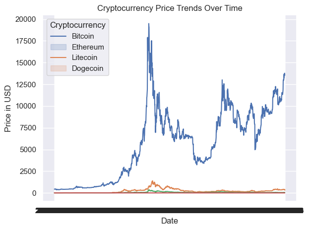

```python
plt.Figure(figsize=(15, 7.5))
subdata = data.loc[data["crypto_name"].isin(popular_coins)]

sns.lineplot(data=subdata, x="trade_date", y="price_usd", hue="crypto_name")

plt.title("Cryptocurrency Price Trends Over Time")
plt.xlabel("Date")
plt.ylabel("Price in USD")

plt.legend(title='Cryptocurrency', loc='upper left', labels=popular_coins)
plt.tight_layout()
plt.show(); plt.close()
```

Initial analysis of the price over time of some of the popular cryptos

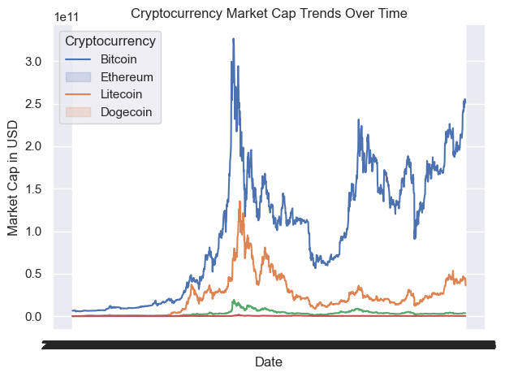

```python
#market cap trends
plt.Figure(figsize=(15, 7.5))
subdata = data.loc[data["crypto_name"].isin(popular_coins)]

sns.lineplot(data=subdata, x="trade_date", y="market_cap", hue="crypto_name")

plt.title("Cryptocurrency Market Cap Trends Over Time")
plt.xlabel("Date")
plt.ylabel("Market Cap in USD")

plt.legend(title='Cryptocurrency', loc='upper left', labels=popular_coins)
plt.tight_layout()
plt.show(); plt.close()
```

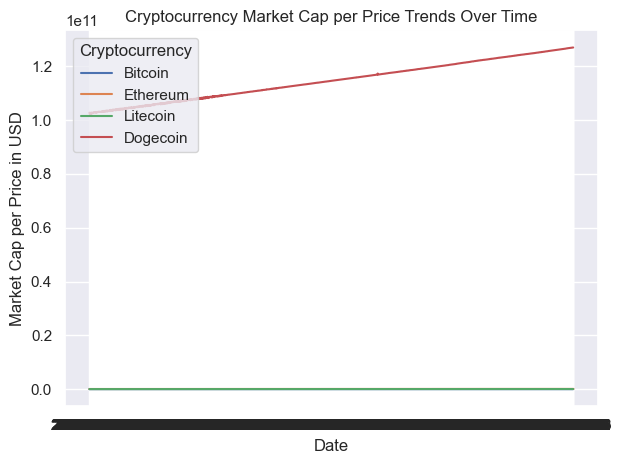

```python
#market cap trends
plt.Figure(figsize=(15, 7.5))
# subdata = data.loc[data["crypto_name"].isin(popular_coins)]
subdata["cap_per_price"] = subdata["market_cap"] / subdata["price_usd"]

sns.lineplot(data=subdata, x="trade_date", y="cap_per_price", hue="crypto_name")

plt.title("Cryptocurrency Market Cap per Price Trends Over Time")
plt.xlabel("Date")
plt.ylabel("Market Cap per Price in USD")

plt.legend(title='Cryptocurrency', loc='upper left')
plt.tight_layout()
plt.show(); plt.close()
```

```python
data.head()
```

|  | trade_date | volume | price_usd | price_btc | market_cap | capitalization_change_1_day | USD_price_change_1_day | BTC_price_change_1_day | crypto_name | crypto_type | ticker | max_supply | site_url | github_url | minable | platform_name | industry_name |
| --- | --- | --- | --- | --- | --- | --- | --- | --- | --- | --- | --- | --- | --- | --- | --- | --- | --- |
| 0 | 2016-01-01 | 36278900 | 434.33 | 1.0 | 6.529300e+09 | 0.000000 | 0.000000 | 0.0 | Bitcoin | 0 | BTC | 21000000 | https://bitcoin.org/ | https://github.com/bitcoin/ | 1 | XRP | 'Proof of Work (PoW)' |
| 1 | 2016-01-02 | 30096600 | 433.44 | 1.0 | 6.517390e+09 | -0.001824 | -0.002049 | 0.0 | Bitcoin | 0 | BTC | 21000000 | https://bitcoin.org/ | https://github.com/bitcoin/ | 1 | XRP | 'Proof of Work (PoW)' |
| 2 | 2016-01-03 | 39633800 | 430.01 | 1.0 | 6.467430e+09 | -0.007666 | -0.007913 | 0.0 | Bitcoin | 0 | BTC | 21000000 | https://bitcoin.org/ | https://github.com/bitcoin/ | 1 | XRP | 'Proof of Work (PoW)' |
| 3 | 2016-01-04 | 38477500 | 433.09 | 1.0 | 6.515713e+09 | 0.007466 | 0.007163 | 0.0 | Bitcoin | 0 | BTC | 21000000 | https://bitcoin.org/ | https://github.com/bitcoin/ | 1 | XRP | 'Proof of Work (PoW)' |
| 4 | 2016-01-05 | 34522600 | 431.96 | 1.0 | 6.500393e+09 | -0.002351 | -0.002609 | 0.0 | Bitcoin | 0 | BTC | 21000000 | https://bitcoin.org/ | https://github.com/bitcoin/ | 1 | XRP | 'Proof of Work (PoW)' |

```python
data.info()
```

```
<class 'pandas.core.frame.DataFrame'>
RangeIndex: 2382623 entries, 0 to 2382622
Data columns (total 17 columns):
 #   Column                       Dtype
---  ------                       -----
 0   trade_date                   object
 1   volume                       Int64
 2   price_usd                    float64
 3   price_btc                    float64
 4   market_cap                   float64
 5   capitalization_change_1_day  float64
 6   USD_price_change_1_day       float64
 7   BTC_price_change_1_day       float64
 8   crypto_name                  object
 9   crypto_type                  Int64
 10  ticker                       object
 11  max_supply                   Int64
 12  site_url                     object
 13  github_url                   object
 14  minable                      Int64
 15  platform_name                object
 16  industry_name                object
dtypes: Int64(4), float64(6), object(7)
memory usage: 318.1+ MB
```

```python
data["trade_date"] = pd.to_datetime(data["trade_date"])
```

The trade date almost slipped the preprocessing, it is now converted to the right format.

```python
# feature correlations

correlation_matrix = data.select_dtypes(exclude=["object", "datetime"]).corr(method='pearson')
```

```python
correlation_matrix
```

|  | volume | price_usd | price_btc | market_cap | capitalization_change_1_day | USD_price_change_1_day | BTC_price_change_1_day | crypto_type | max_supply | minable |
| --- | --- | --- | --- | --- | --- | --- | --- | --- | --- | --- |
| volume | 1.000000 | -0.000171 | -0.000170 | -0.000018 | -0.000024 | -0.000158 | -0.000159 | -0.014143 | -0.000168 | 0.021726 |
| price_usd | -0.000171 | 1.000000 | 0.998659 | -0.000009 | -0.000003 | -0.000019 | -0.000019 | 0.004437 | -0.000123 | -0.003101 |
| price_btc | -0.000170 | 0.998659 | 1.000000 | -0.000009 | -0.000003 | -0.000019 | -0.000020 | 0.004430 | -0.000197 | -0.003097 |
| market_cap | -0.000018 | -0.000009 | -0.000009 | 1.000000 | 0.004697 | 0.000227 | 0.000252 | 0.001649 | -0.000011 | -0.001151 |
| capitalization_change_1_day | -0.000024 | -0.000003 | -0.000003 | 0.004697 | 1.000000 | 0.050131 | 0.050497 | 0.000607 | -0.000006 | -0.000427 |
| USD_price_change_1_day | -0.000158 | -0.000019 | -0.000019 | 0.000227 | 0.050131 | 1.000000 | 0.999836 | -0.001393 | -0.000011 | 0.001616 |
| BTC_price_change_1_day | -0.000159 | -0.000019 | -0.000020 | 0.000252 | 0.050497 | 0.999836 | 1.000000 | -0.001410 | -0.000011 | 0.001629 |
| crypto_type | -0.014143 | 0.004437 | 0.004430 | 0.001649 | 0.000607 | -0.001393 | -0.001410 | 1.000000 | 0.004305 | -0.688622 |
| max_supply | -0.000168 | -0.000123 | -0.000197 | -0.000011 | -0.000006 | -0.000011 | -0.000011 | 0.004305 | 1.000000 | -0.003097 |
| minable | 0.021726 | -0.003101 | -0.003097 | -0.001151 | -0.000427 | 0.001616 | 0.001629 | -0.688622 | -0.003097 | 1.000000 |

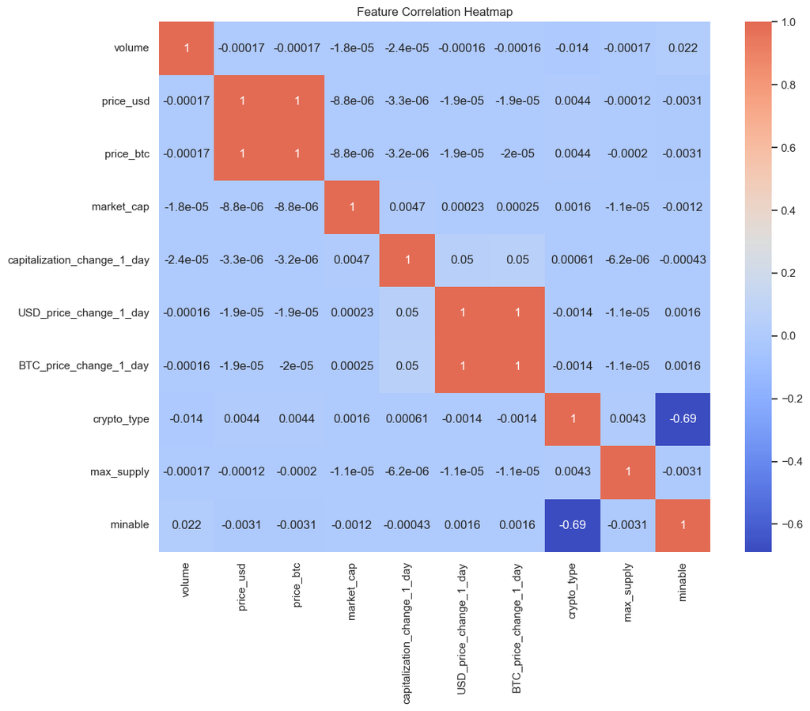

```python
# correlation heatmap
plt.figure(figsize=(12, 10))

sns.heatmap(correlation_matrix, annot=True, cmap='coolwarm', center=0.3)
plt.title("Feature Correlation Heatmap")
plt.tight_layout()
plt.show(); plt.close()
```

# Data Preparation

This model will be made using BTC, so BTC data is extracted from the dataset.

```python
# filter away non - Bitcoin records; select useful features
df = data.loc[data["crypto_name"] == "Bitcoin", ["trade_date", "price_usd"]]
```

```python
df.head()
```

|  | trade_date | price_usd |
| --- | --- | --- |
| 0 | 2016-01-01 | 434.33 |
| 1 | 2016-01-02 | 433.44 |
| 2 | 2016-01-03 | 430.01 |
| 3 | 2016-01-04 | 433.09 |
| 4 | 2016-01-05 | 431.96 |

```python
df.set_index("trade_date", inplace=True)
```

```python
df.head()
```

| trade_date | price_usd |
| --- | --- |
| 2016-01-01 | 434.33 |
| 2016-01-02 | 433.44 |
| 2016-01-03 | 430.01 |
| 2016-01-04 | 433.09 |
| 2016-01-05 | 431.96 |

```python
# make data periodic

period = "D"
df.index = pd.DatetimeIndex(df.index).to_period(period)
```

```python
df.shape
```

```
(1746, 1)
```

# Data Modelling

1. ARIMA
2. SARIMAX
3. Exponential Smoothing
4. Holt-Winters Exponential Smoothing

```python
# augmented Dickey-Fuller test
from statsmodels.tsa.stattools import adfuller
```

For the models to work, the data will need to be stationary

```python
results = adfuller(df.values)
```

```python
results
```

```
(np.float64(-1.657200497392826),
 np.float64(0.4532879108051502),
 20,
 1725,
 {'1%': np.float64(-3.4341465551936534),
  '5%': np.float64(-2.863216966926812),
  '10%': np.float64(-2.567662770090317)},
 np.float64(24725.432195324942))
```

```python
adf, pvalue, lag, num_obs, d, _ = results
```

```python
adf
```

```
np.float64(-1.657200497392826)
```

```python
pvalue
```

```
np.float64(0.4532879108051502)
```

```python
d
```

```
{'1%': np.float64(-3.4341465551936534),
 '5%': np.float64(-2.863216966926812),
 '10%': np.float64(-2.567662770090317)}
```

The Data is not stationary. This will need to be fixed.

```python
def make_stationary(data, lag=1):
    for _ in range(lag):
        data = data.diff()
    return data.dropna()
```

```python
new_df = make_stationary(df)
```

```python
new_df.isnull().sum()
```

```
price_usd    0
dtype: int64
```

```python
adfuller(new_df.values)
```

```
(np.float64(-8.207849239436241),
 np.float64(6.946387416930824e-13),
 19,
 1725,
 {'1%': np.float64(-3.4341465551936534),
  '5%': np.float64(-2.863216966926812),
  '10%': np.float64(-2.567662770090317)},
 np.float64(24712.881485669288))
```

```python
import statsmodels.api as sm

from statsmodels.tsa.statespace.sarimax import SARIMAX
from statsmodels.tsa.statespace.exponential_smoothing import ExponentialSmoothing
from statsmodels.tsa.holtwinters import ExponentialSmoothing as HoltExponentialSmoothing
```

While the model can be tested first before optimisation, in this case, I optimise the models, then build the models with the optimised parameters.

```python
def obtain_best_hyperparameters(aic_values, bic_values, pq_values):
    best_aic = min(aic_values)
    best_bic = min(bic_values)

    best_ix = aic_values.index(best_aic)
    best_params = pq_values[best_ix]

    for i in range(len(aic_values)):
        print(f"AIC = {aic_values[i]}, BIC = {bic_values[i]}, (p, q) = {pq_values[i]}")

    return best_aic, best_bic, best_params
```

```python
def optimise_exponential_model(model, data, **kwargs):
    #extract hyperparameters
    trends = kwargs["trend"]
    damped_trends = kwargs["damped_trend"]
    seasonals = kwargs["seasonal"]
    seasonal_periods_list = kwargs["seasonal_periods"]
    use_boxcox_list = kwargs["use_boxcox"]

    aic_values, bic_values, pq_values = [], [], [] # store aic, bic and hyperparameters

    for trend in trends:
        for damped_trend in damped_trends:
            for seasonal in seasonals:
                for seasonal_periods in seasonal_periods_list:
                    for use in use_boxcox_list:
                        try:
                            # instantiate model
                            try: # holt winters model
                                exp_model = model(
                                    endog = data, trend = trend, seasonal = seasonal, seasonal_periods = seasonal_periods,
                                    damped_trend = damped_trend, use_boxcox = use
                                    )
                            except: # simple exponential smoothing model
                                exp_model = model(
                                    endog = data, trend = trend, seasonal = seasonal_periods,
                                    damped_trend = damped_trend
                                    )

                            # train model
                            try:
                                results = exp_model.fit(maxiter = kwargs["max_iter"])
                            except:
                                results = exp_model.fit()

                            r = get_metrics(results = results) # extract metrics

                            aic_values.append(r["AIC"])
                            bic_values.append(r["BIC"])

                            # store hyperparameters
                            params = {
                                "trend": trend,
                                "damped_trend": damped_trend,
                                "seasonal": seasonal,
                                "seasonal_period": seasonal_periods,
                                "use_boxcox": use

                            }

                            pq_values.append(params) #store hyperparameters

                        except:
                            exp_model = None
                            pass

    seasonal_order = None
    best_aic, best_bic, best_params = obtain_best_hyperparameters(aic_values, bic_values, pq_values) # extract best hyperparameters

    return best_aic, best_bic, best_params, seasonal_order
```

```python
def optimise_arima_model(model, data, **kwargs):
    #extract hyperparameters
    p_range = q_range = list(range(kwargs["lower"], kwargs["upper"]))
    d = kwargs["d"]

    aic_values, bic_values, pq_values = [], [], [] # store aic, bic and hyperparameters
    seasonal_order = None

    for p in p_range:
        for q in q_range:
            try:
                # instantiate model
                if model.__name__ == 'SARIMAX':
                    # For SARIMAX model
                    seasonal_order = (p, d, q, kwargs["s"]) if "s" in kwargs else None
                    arima_model = model(endog = data, order = (p, d, q), seasonal_order = seasonal_order)
                    results = arima_model.fit(maxiter = kwargs["max_iter"])
                else:
                    # For ARIMA model
                    arima_model = model(endog = data, order = (p, d, q))
                    results = arima_model.fit()

                r = get_metrics(results = results) # extract metrics

                aic_values.append(r["AIC"])
                bic_values.append(r["BIC"])

                # store hyperparameters
                params = (p, q)
                pq_values.append(params) #store hyperparameters

            except Exception as e:
                # Skip this parameter combination if it fails
                continue

    if not aic_values:  # If no successful fits
        print("No successful model fits found!")
        return None, None, None, None

    best_aic, best_bic, best_params = obtain_best_hyperparameters(aic_values, bic_values, pq_values) # extract best hyperparameters

    return best_aic, best_bic, best_params, seasonal_order
```

```python
def get_metrics(results):
    string = results.summary().__str__().split("\n")
    aic = string[4].split("AIC:")[-1].strip()
    bic = string[5].split("BIC")[-1].strip()

    return {
        "AIC": float(aic) if "." in aic else int(aic),
        "BIC": float(bic) if "." in bic else int(bic)
    }
```

```python
def optimise_models(model, data, **kwargs):
    try:
        return optimise_arima_model(model, data, **kwargs)
    except:
        return optimise_exponential_model(model, data, **kwargs)
```

```python
# arima and sarima model optimisation

arima_params = {
    "lower": 0,
    "upper": 10,
    "d": 1,
    "s": 1,
    "max_iter": 500
}
```

```python
# holt
holt_params = {
    "trend": ["add", "mul", "multiplicative", "additive"],
    "damped_trend": [True, False],
    "seasonal": ["add", "mul", "multiplicative", "additive"],
    "seasonal_periods": [1, 4, 6, 12],
    "use_boxcox": [True, False],
    "max_iter": 500
}
```

```python
# exponential smoothing model optimisation
exp_params = {
    k: v for k, v in holt_params.items() if k not in ["seasonal_periods", "use_boxcox"]
}

exp_params["seasonal"] = holt_params["seasonal_periods"]
```

```python
# Create separate optimization functions for each model type to avoid conflicts

def optimise_holt_winters_model(data, **kwargs):
    """Optimize Holt-Winters Exponential Smoothing model"""
    trends = kwargs["trend"]
    damped_trends = kwargs["damped_trend"]
    seasonals = kwargs["seasonal"]
    # Use correct parameter name - it's seasonal_period not seasonal_periods in holt_params
    seasonal_periods_list = kwargs.get("seasonal_periods", kwargs.get("seasonal_period", [1, 4, 6, 12]))
    use_boxcox_list = kwargs["use_boxcox"]

    # Ensure data is in the right format
    if isinstance(data, pd.DataFrame):
        data_series = data.iloc[:, 0]  # Take first column
    else:
        data_series = data

    aic_values, bic_values, param_values = [], [], []
    successful_fits = 0
    total_attempts = 0

    print("Testing Holt-Winters parameter combinations...")

    for trend in trends[:2]:  # Limit to reduce computation
        for damped_trend in damped_trends:
            for seasonal in seasonals[:2]:  # Limit to reduce computation
                for seasonal_periods in seasonal_periods_list:
                    for use_boxcox in use_boxcox_list:
                        total_attempts += 1
                        try:
                            model = HoltExponentialSmoothing(
                                endog=data_series,
                                trend=trend,
                                seasonal=seasonal,
                                seasonal_periods=seasonal_periods,
                                damped_trend=damped_trend,
                                use_boxcox=use_boxcox
                            )
                            results = model.fit(maxiter=kwargs["max_iter"])

                            aic_values.append(results.aic)
                            bic_values.append(results.bic)
                            param_values.append({
                                "trend": trend,
                                "damped_trend": damped_trend,
                                "seasonal": seasonal,
                                "seasonal_periods": seasonal_periods,
                                "use_boxcox": use_boxcox
                            })
                            successful_fits += 1

                            if successful_fits <= 3:
                                print(f"Success: {trend}/{seasonal}/{seasonal_periods} -> AIC={results.aic:.2f}")
                        except Exception as e:
                            if total_attempts <= 3:
                                print(f"Failed: {trend}/{seasonal}/{seasonal_periods} -> {type(e).__name__}")
                            continue

    print(f"Completed: {successful_fits}/{total_attempts} successful Holt-Winters fits")

    if not aic_values:
        print("No successful Holt-Winters model fits found!")
        return None, None, None, None

    best_idx = aic_values.index(min(aic_values))
    best_aic = aic_values[best_idx]
    best_bic = bic_values[best_idx]
    best_params = param_values[best_idx]

    print(f"Best Holt-Winters: AIC={best_aic:.2f}")

    return best_aic, best_bic, best_params, None

def optimise_simple_exp_smoothing_model(data, **kwargs):
    """Optimize Simple Exponential Smoothing model"""
    # Use seasonal as the periods parameter for simple exponential smoothing
    seasonal_periods_list = kwargs["seasonal"]

    # Ensure data is in the right format
    if isinstance(data, pd.DataFrame):
        data_series = data.iloc[:, 0]  # Take first column
    else:
        data_series = data

    aic_values, bic_values, param_values = [], [], []
    successful_fits = 0
    total_attempts = 0

    print("Testing Simple Exponential Smoothing parameter combinations...")

    for seasonal_periods in seasonal_periods_list:
        total_attempts += 1
        try:
            model = ExponentialSmoothing(
                endog=data_series,
                trend=None,
                seasonal=seasonal_periods,
                damped_trend=False
            )
            results = model.fit(maxiter=kwargs["max_iter"])

            aic_values.append(results.aic)
            bic_values.append(results.bic)
            param_values.append({
                "seasonal": seasonal_periods
            })
            successful_fits += 1

            if successful_fits <= 3:
                print(f"Success: seasonal={seasonal_periods} -> AIC={results.aic:.2f}")
        except Exception as e:
            if total_attempts <= 3:
                print(f"Failed: seasonal={seasonal_periods} -> {type(e).__name__}")
            continue

    print(f"Completed: {successful_fits}/{total_attempts} successful Simple Exp Smoothing fits")

    if not aic_values:
        print("No successful Simple Exponential Smoothing model fits found!")
        return None, None, None, None

    best_idx = aic_values.index(min(aic_values))
    best_aic = aic_values[best_idx]
    best_bic = bic_values[best_idx]
    best_params = param_values[best_idx]

    print(f"Best Simple Exp Smoothing: AIC={best_aic:.2f}")

    return best_aic, best_bic, best_params, None
```

```python
def optimise_sarimax_simple(data, **kwargs):
    """Simple SARIMAX optimization without problematic parameters"""
    p_range = list(range(kwargs["lower"], kwargs["upper"]))
    q_range = list(range(kwargs["lower"], kwargs["upper"]))
    d = kwargs["d"]
    s = kwargs["s"]

    # Ensure data is in the right format
    if isinstance(data, pd.DataFrame):
        data_series = data.iloc[:, 0]  # Take first column
    else:
        data_series = data

    aic_values, bic_values, pq_values = [], [], []
    successful_fits = 0
    total_attempts = 0

    print(f"Testing {len(p_range) * len(q_range)} SARIMAX parameter combinations...")

    for p in p_range:
        for q in q_range:
            total_attempts += 1
            try:
                sarimax_model = SARIMAX(
                    endog=data_series,
                    order=(p, d, q)
                )
                results = sarimax_model.fit(maxiter=kwargs.get("max_iter", 500), disp=False)

                aic_values.append(results.aic)
                bic_values.append(results.bic)
                pq_values.append((p, q))
                successful_fits += 1

                if successful_fits <= 5:
                    print(f"Success: (p,d,q)=({p},{d},{q}) -> AIC={results.aic:.2f}")

            except Exception as e:
                if total_attempts <= 5:
                    print(f"Failed: (p,d,q)=({p},{d},{q}) -> {type(e).__name__}")
                continue

    print(f"Completed: {successful_fits}/{total_attempts} successful SARIMAX fits")

    if not aic_values:
        print("No successful SARIMAX model fits found!")
        return None, None, None, None

    best_idx = aic_values.index(min(aic_values))
    best_aic = aic_values[best_idx]
    best_bic = bic_values[best_idx]
    best_params = pq_values[best_idx]

    print(f"Best SARIMAX: (p,d,q)=({best_params[0]},{d},{best_params[1]}) -> AIC={best_aic:.2f}")

    return best_aic, best_bic, best_params, None
```

```python
# Simplified ARIMA optimization function
def optimise_arima_simple(data, **kwargs):
    """Simple ARIMA optimization without problematic parameters"""
    p_range = list(range(kwargs["lower"], kwargs["upper"]))
    q_range = list(range(kwargs["lower"], kwargs["upper"]))
    d = kwargs["d"]

    # Ensure data is in the right format
    if isinstance(data, pd.DataFrame):
        data_series = data.iloc[:, 0]  # Take first column
    else:
        data_series = data

    aic_values, bic_values, pq_values = [], [], []
    successful_fits = 0
    total_attempts = 0

    print(f"Testing {len(p_range) * len(q_range)} ARIMA parameter combinations...")

    for p in p_range:
        for q in q_range:
            total_attempts += 1
            try:
                arima_model = sm.tsa.arima.ARIMA(endog=data_series, order=(p, d, q))
                results = arima_model.fit()  # Use default parameters

                aic_values.append(results.aic)
                bic_values.append(results.bic)
                pq_values.append((p, q))
                successful_fits += 1

                if successful_fits <= 5:
                    print(f"Success: (p,d,q)=({p},{d},{q}) -> AIC={results.aic:.2f}")

            except Exception as e:
                if total_attempts <= 5:
                    print(f"Failed: (p,d,q)=({p},{d},{q}) -> {type(e).__name__}")
                continue

    print(f"Completed: {successful_fits}/{total_attempts} successful ARIMA fits")

    if not aic_values:
        print("No successful ARIMA model fits found!")
        return None, None, None, None

    best_idx = aic_values.index(min(aic_values))
    best_aic = aic_values[best_idx]
    best_bic = bic_values[best_idx]
    best_params = pq_values[best_idx]

    print(f"Best ARIMA: (p,d,q)=({best_params[0]},{d},{best_params[1]}) -> AIC={best_aic:.2f}")

    return best_aic, best_bic, best_params, None
```

```python
sarima_test_params = {
    "lower": 0,
    "upper": 5,  # Reduced range for quicker testing
    "d": 1,
    "s": 1,  # No seasonality for simplicity
    "max_iter": 100  # Reduced iterations for quicker testing
}

print("Optimizing SARIMA model...")
sarimax_aic, sarimax_bic, sarimax_params, sarimax_seasonal_order = optimise_sarimax_simple(df, **sarima_test_params)
```

```
Optimizing SARIMA model...
Testing 25 SARIMAX parameter combinations...
Success: (p,d,q)=(0,1,0) -> AIC=25106.02
Success: (p,d,q)=(0,1,1) -> AIC=25107.52
Success: (p,d,q)=(0,1,2) -> AIC=25109.41
Success: (p,d,q)=(0,1,3) -> AIC=25111.40
Success: (p,d,q)=(0,1,4) -> AIC=25110.47
```

[output not shown]

```
Completed: 25/25 successful SARIMAX fits
Best SARIMAX: (p,d,q)=(4,1,2) -> AIC=25094.02
```

```python
# Test with smaller parameter range for ARIMA first
arima_test_params = {
    "lower": 0,
    "upper": 3,  # Smaller range
    "d": 1,
    "max_iter": 500
}

print("Testing ARIMA optimization with smaller range...")
arima_aic, arima_bic, new_arima_params, arima_seasonal_order = optimise_arima_simple(df, **arima_test_params)
```

```
Testing ARIMA optimization with smaller range...
Testing 9 ARIMA parameter combinations...
Success: (p,d,q)=(0,1,0) -> AIC=25106.02
Success: (p,d,q)=(0,1,1) -> AIC=25107.52
Success: (p,d,q)=(0,1,2) -> AIC=25109.41
Success: (p,d,q)=(1,1,0) -> AIC=25107.52
Success: (p,d,q)=(1,1,1) -> AIC=25106.62
```

```
Completed: 9/9 successful ARIMA fits
Best ARIMA: (p,d,q)=(0,1,0) -> AIC=25106.02
```

```python
# Optimize Simple Exponential Smoothing model
print("Optimizing Simple Exponential Smoothing model...")
exp_aic, exp_bic, new_exp_params, exp_seasonal_order = optimise_simple_exp_smoothing_model(df, **exp_params)
```

```
Optimizing Simple Exponential Smoothing model...
Testing Simple Exponential Smoothing parameter combinations...
Failed: seasonal=1 -> ValueError
Success: seasonal=4 -> AIC=25128.09
Success: seasonal=6 -> AIC=25132.48
Success: seasonal=12 -> AIC=25140.00
Completed: 3/4 successful Simple Exp Smoothing fits
Best Simple Exp Smoothing: AIC=25128.09
```

```python
# Optimize Holt-Winters model
print("Optimizing Holt-Winters model...")
holt_aic, holt_bic, new_holt_params, holt_seasonal_order = optimise_holt_winters_model(df, **holt_params)
```

```
Optimizing Holt-Winters model...
Testing Holt-Winters parameter combinations...
Failed: add/add/1 -> ValueError
Failed: add/add/1 -> ValueError
Failed: add/add/4 -> TypeError
Completed: 0/64 successful Holt-Winters fits
No successful Holt-Winters model fits found!
```

```python
# Summary: All Model Optimization Results
print("="*60)
print("MODEL OPTIMIZATION SUMMARY")
print("="*60)

print("\n1. SARIMAX Model:")
print(f"   Best parameters: (p,d,q) = {sarimax_params}")
print(f"   AIC: {sarimax_aic:.2f}")
print(f"   BIC: {sarimax_bic:.2f}")

print("\n2. ARIMA Model:")
if arima_aic is not None:
    print(f"   Best parameters: (p,d,q) = {new_arima_params}")
    print(f"   AIC: {arima_aic:.2f}")
    print(f"   BIC: {arima_bic:.2f}")
else:
    print("   FAILED - No successful fits")

print("\n3. Simple Exponential Smoothing:")
if exp_aic is not None:
    print(f"   Best parameters: {new_exp_params}")
    print(f"   AIC: {exp_aic:.2f}")
    print(f"   BIC: {exp_bic:.2f}")
else:
    print("   FAILED - No successful fits")

print("\n4. Holt-Winters Exponential Smoothing:")
try:
    if holt_aic is not None:
        print(f"   Best parameters: {new_holt_params}")
        print(f"   AIC: {holt_aic:.2f}")
        print(f"   BIC: {holt_bic:.2f}")
    else:
        print("   FAILED - No successful fits")
except:
    print("   FAILED - No successful fits")

print("\n" + "="*60)

# Compare models that worked
working_models = []
if sarimax_aic is not None:
    working_models.append(("SARIMAX", sarimax_aic))
if arima_aic is not None:
    working_models.append(("ARIMA", arima_aic))
if exp_aic is not None:
    working_models.append(("Simple Exp Smoothing", exp_aic))

if working_models:
    print("BEST MODEL RANKING (by AIC):")
    working_models.sort(key=lambda x: x[1])  # Sort by AIC
    for i, (model_name, aic) in enumerate(working_models, 1):
        print(f"   {i}. {model_name}: AIC = {aic:.2f}")
else:
    print("No working models found!")

print("="*60)
```

```
============================================================
MODEL OPTIMIZATION SUMMARY
============================================================

1. SARIMAX Model:
   Best parameters: (p,d,q) = (4, 2)
   AIC: 25094.02
   BIC: 25132.27

2. ARIMA Model:
   Best parameters: (p,d,q) = (0, 0)
   AIC: 25106.02
   BIC: 25111.49

3. Simple Exponential Smoothing:
   Best parameters: {'seasonal': 4}
   AIC: 25128.09
   BIC: 25166.35

4. Holt-Winters Exponential Smoothing:
   FAILED - No successful fits

============================================================
BEST MODEL RANKING (by AIC):
   1. SARIMAX: AIC = 25094.02
   2. ARIMA: AIC = 25106.02
   3. Simple Exp Smoothing: AIC = 25128.09
============================================================
```